# Cartes Minimalistes

Arthur Charpentier

07/09/2015

Le logiciel R peut être installé, librement et gratuitement, depuis un des dépôts du [CRAN](https://cran.r-project.org/) (Comprehensive R Archive Network), ou, pour un éditeur plus convivial, via [RStudio](https://www.rstudio.com/products/rstudio/download/). Une des richesses de R, c’est sa (vaste) communauté d’utilisateurs, qui partagent des librairies de fonctions (appelées *packages*), par exemple en [cartographie](https://cran.r-project.org/web/views/Spatial.html). Ces librairies proposent divers outils comme des fonctions ou des bases de données.

Pour installer un package, on emploie la commande :

```r
install.packages("maps",dependencies=TRUE,repos='http://cran.us.r-project.org')
```

Cette instruction va installer sur notre disque dur les divers objets du package `maps`. Ces fonctions doivent ensuite être chargées en mémoire :

```r
library(maps)
```

Cependant, le package `maps` est peut-être déjà installé sur notre système : inutile, dans ce cas, de le télécharger à nouveau. Introduisons dès à présent une fonction qui permet de ne télécharger qu’une fois :

```r
libload <- function(libx) {
  if(!require(libx, character.only=TRUE)){
    install.packages(libx,dependencies=TRUE,repos='http://cran.us.r-project.org')
  }
  return (library(libx, character.only=TRUE))
}
```

Puis:

```r
libload('maps')
```

## 1. Les villes

Le package `maps` contient, entre autres choses, une base de la localisation des principales villes du monde, dont on peut afficher un extrait de quelques lignes ainsi :

```r
data("world.cities")
tail(world.cities[,c(1,2,4,5)])
```

```
##                  name  country.etc   lat  long
## 43640      az-Zubarah        Qatar 26.12 51.17
## 43641       az-Zubayr         Iraq 30.39 47.71
## 43642        az-Zulfi Saudi Arabia 26.30 44.80
## 43643   az-Zuwaytinah        Libya 30.95 20.12
## 43644    s-Gravenhage  Netherlands 52.07  4.30
## 43645 s-Hertogenbosch  Netherlands 51.68  5.30
```

Les quatre colonnes de données affichées sont: le nom de la ville (1), son pays (2), sa latitude (4) et sa longitude (5). (La base contient d’autres éléments, comme par exemple la population, champ numéro 3.)

Pour obtenir le premier graphique, on emploie la fonction `plot()`, qui trace des points, en indiquant les longitude (`world.cities$lon`) et latitude (`world.cities$lon`) de chaque ville, avec des points pleins (option `pch=19`) et pas trop gros (`cex=.7`) – n’oublions pas qu’il y a 43 645 points à représenter sur la “carte” –, sans dessiner ni axe ni libellés :

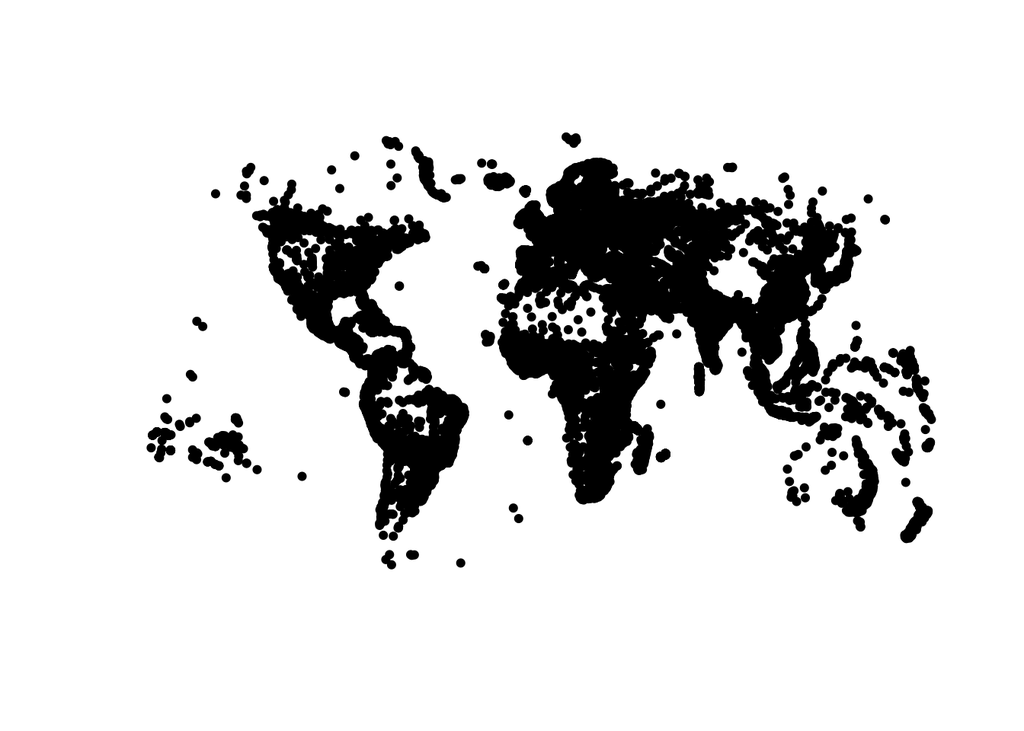

```r
plot(world.cities$lon,world.cities$lat,pch=19,cex=.7,axes=FALSE,xlab="",ylab="")
```

L’image est un peu trop dense à notre goût, on va la simplifier en affichant moins de points. Par exemple, en se limitant aux villes de plus de 100 000 habitants. Le plus simple est de filtrer le contenu pour n’en retenir qu’une sous-base :

```r
world.cities.sub = subset(world.cities,pop>100000)
```

et de reprendre le code précédent:

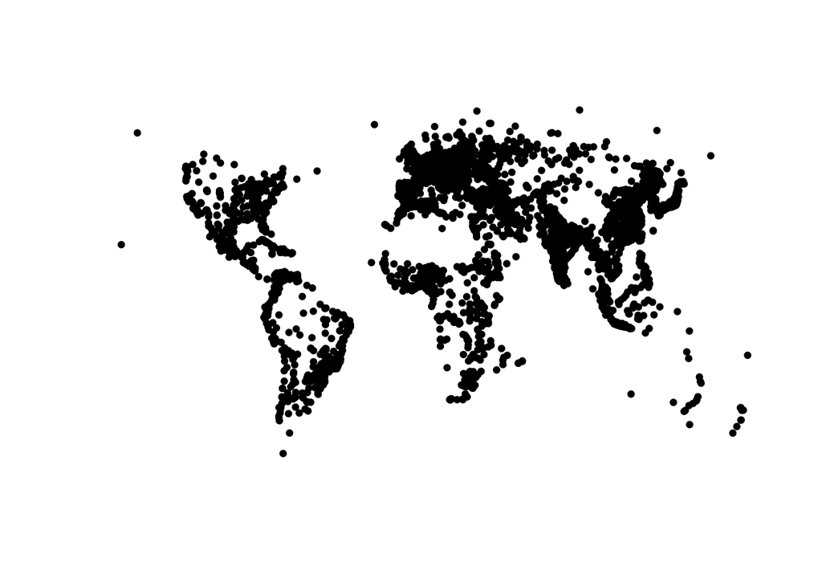

```r
plot(world.cities.sub$lon,world.cities.sub$lat,pch=19,cex=.7,axes=FALSE,xlab="",ylab="")
```

Cette fois, seules 4 251 villes sont représentées.

## 1.bis Projection

On notera qu’il est possible de choisir une autre projection géographique. Pour changer de système, on peut utiliser la fonction suivante :

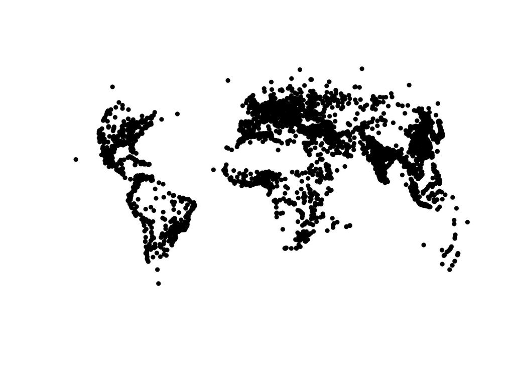

```r
libload('mapproj')
xy=mapproject(world.cities.sub$lon,world.cities.sub$lat, projection="gilbert")
plot(xy$x,xy$y,pch=19,cex=.7,axes=FALSE,xlab="",ylab="")
```

qui donne une projection de [Gilbert](https://www.jasondavies.com/maps/gilbert/). On peut aussi visualiser une projection de type [Lambert](https://en.wikipedia.org/wiki/Lambert_conformal_conic_projection),

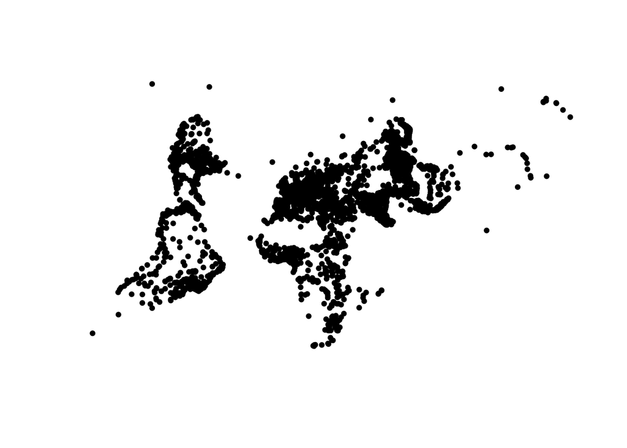

```r
xy=mapproject(world.cities.sub$lon,world.cities.sub$lat, projection="lambert",param=c(50,10))
plot(xy$x,xy$y,pch=19,cex=.7,axes=FALSE,xlab="",ylab="")
```

## 2. Les aéroports

Dans la plupart des situations, les données nécessaires pour créer une carte ne se trouvent pas dans un package, et il convient de les trouver sur un site.

C’est le cas pour la localisation des aéroports. Les bases de données proposées par le site [openflights.org](http://openflights.org/data.html#airport) en référencent près de 7 000. Une base plus petite (probablement uniquement les aéroports internationaux) se trouve sur le site [Natural Earth](http://www.naturalearthdata.com/downloads/10m-cultural-vectors/). Il faut télécharger, puis importer la base sous R.

On commence par deux fonctions qui permettront de ne télécharger les données qu’une fois :

```r
getdata <- function(url, file) {
  if (!file.exists(file)) {
    download.file(url,destfile=file)
  }
}

getdatazip <- function(url, file, exdir) {
  if (!file.exists(file)) {
    download.file(url,destfile=file)
    unzip(file, exdir=exdir)
  }
}
```

puis on télécharge les données :

```r
dir.create('data')
getdatazip( "http://www.naturalearthdata.com/http//www.naturalearthdata.com/download/10m/cultural/ne_10m_airports.zip", 'data/aeroports.zip', 'data/aeroports/')
list.files('data/aeroports/')
```

```
## [1] "ne_10m_airports.dbf"         "ne_10m_airports.prj"
## [3] "ne_10m_airports.README.html" "ne_10m_airports.shp"
## [5] "ne_10m_airports.shx"         "ne_10m_airports.VERSION.txt"
```

On obtient ainsi un ensemble de fichiers qui composent un *shapefile*; ils contiennent des objets géoréférencés, comme des lignes, des polygones ou des points. Pour importer ce shapefile dans R, il convient d’installer le package dédié :

```r
libload("maptools")
```

```
## Checking rgeos availability: FALSE
##      Note: when rgeos is not available, polygon geometry     computations in maptools depend on gpclib,
##      which has a restricted licence. It is disabled by default;
##      to enable gpclib, type gpclibPermit()
```

On charge ensuite les fonctions en mémoire, et on utilise la fonction `readShapePoints()` (la base des aéroports est une collection de points géographiques).

```r
shape <- readShapePoints("data/aeroports/ne_10m_airports.shp")
```

Les 890 aéroports ont les coordonnées suivantes

```r
tail(shape@coords)
```

```
##      coords.x1  coords.x2
## 885 -43.248381 -22.812344
## 886  -3.569027  40.468128
## 887 -66.004230  18.438077
## 888  17.930730  59.651120
## 889 106.654296  -6.126603
## 890  23.947116  37.936233
```

que l’on peut visualiser avec la commande

[figure not shown]

```r
plot(shape,pch=19,cex=.7)
```

## 3. Les ports maritimes

Tant qu’on est sur un format de points, le processus est toujours le même. La seule difficulté est de trouver les bases localisant des points intéressants.

Autre exemple, les {ports} se trouvent aussi sur [http://www.naturalearthdata.com/](http://www.naturalearthdata.com/downloads/10m-cultural-vectors/) :

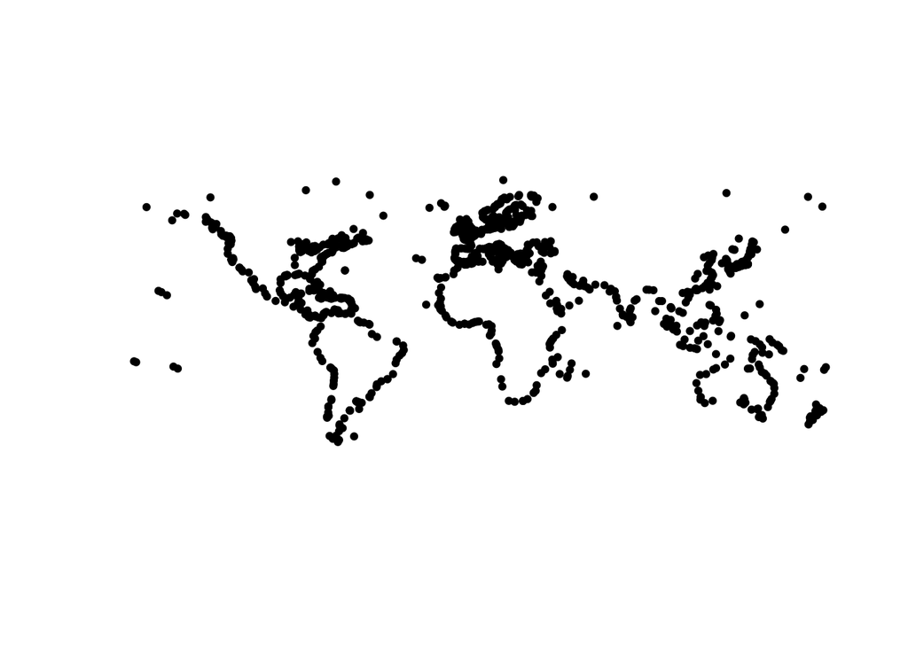

```r
getdatazip( "http://www.naturalearthdata.com/http//www.naturalearthdata.com/download/10m/cultural/ne_10m_ports.zip", 'data/ports.zip', 'data/ports/')
loc=""
shape <- readShapePoints("data/ports/ne_10m_ports.shp")
plot(shape,pch=19,cex=.7)
```

## 4. Les rivières

Une base de données des rivières sur trouve sur [github.com/jjrom/hydre](https://github.com/jjrom/hydre/tree/master/mapserver/geodata/rivers). Ces données sont un peu plus difficiles à récupérer, car elles ne sont pas au format zip mais en 7 fichiers à télécharger individuellement.

```r
loc="https://raw.githubusercontent.com/jjrom/hydre/master/mapserver/geodata/rivers/GRDC_687_rivers"
ext=c(".dbf",".prj",".sbn",".sbx",".shp",".shp.xml",".shx")
dir.create('data/rivieres')
for(i in 1:length(ext)){
 loc1=paste(loc,ext[i],"?raw=true",sep="")
 loc2=paste("data/rivieres/GRDC_687_rivers",ext[i],sep="")
 getdata(loc1,loc2)
}
```

Cette fois-ci, ce qu’on veut visualiser n’est pas constitué de points, mais de lignes. On importe la base avec la fonction `readShapeLines()`.

```r
shape <- readShapeLines("data/rivieres/GRDC_687_rivers.shp")
```

Cet objet est un peu plus complexe que le précédent. Chaque “rivière” est une collection de lignes. Il y en a ici 687. La troisième rivière de la liste est décrite par l’objet `shape@lines[[3]]`, qui est une liste composée de lignes, correspondant à autant de tronçons de rivière que nécessaire. Ainsi, le cinquième tronçon de la troisième rivière est caractérisé par les points `shape@lines[[3]]@Lines [[5]]`

```r
shape@lines[[3]]@Lines[[5]]
```

```
## An object of class "Line"
## Slot "coords":
##            [,1]     [,2]
##  [1,] -161.9773 61.56081
##  [2,] -162.0067 61.55999
##  [3,] -162.0303 61.56082
##  [4,] -162.0411 61.56194
##  [5,] -162.0697 61.56777
##  [6,] -162.0817 61.57639
##  [7,] -162.0855 61.58250
##  [8,] -162.0864 61.58860
##  [9,] -162.0783 61.59749
## [10,] -162.0725 61.60139
## [11,] -162.0650 61.60500
## [12,] -162.0378 61.61361
## [13,] -162.0269 61.61583
## [14,] -162.0125 61.61694
## [15,] -161.9892 61.62110
## [16,] -161.9745 61.62838
```

Visuellement, on va relier ces points par des segments; l’opération est plus lourde, car on traite des centaines de milliers de coordonnées. La commande à utiliser est :

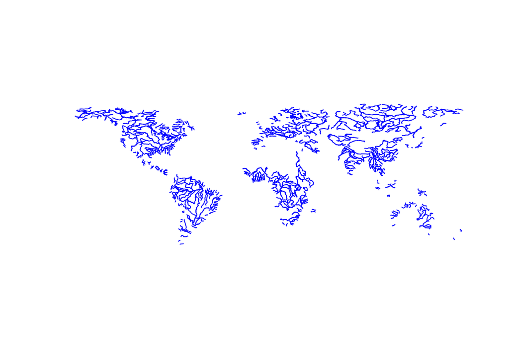

```r
plot(shape,col="blue")
```

## 4.bis Projection

Là encore, on peut changer le système de représentation. C’est un peu plus technique car on n’a pas simplement un vecteur de longitudes, et un vecteur des latitudes.

```r
libload("sp")
libload("rgdal")
```

[output not shown]

Cette fois, c’est lors de la lecture du fichier que l’on on va spécifier son système de projection :

```r
shape <- readShapeLines("data/rivieres/GRDC_687_rivers.shp",proj4string=CRS("+proj=longlat +datum=WGS84"))
```

```
## NOTE: rgdal::checkCRSArgs: no proj_defs.dat in PROJ.4 shared files
```

et pour le modifier (par exemple avec une projection de type Lambert) :

```r
crs.laea <- CRS("+proj=laea +lat_0=52 +lon_0=10 +x_0=4321000 +y_0=3210000 +ellps=GRS80 +units=m +no_defs")
```

```
## NOTE: rgdal::checkCRSArgs: no proj_defs.dat in PROJ.4 shared files
```

```r
shape.nouveau = spTransform(shape,crs.laea)
```

```
## NOTE: rgdal::checkCRSArgs: no proj_defs.dat in PROJ.4 shared files
```

Les sigles sont complexes, mais l’aide de R (ou les divers forums) permet toujours de trouver les sigles des principaux systèmes de représentation. Ici

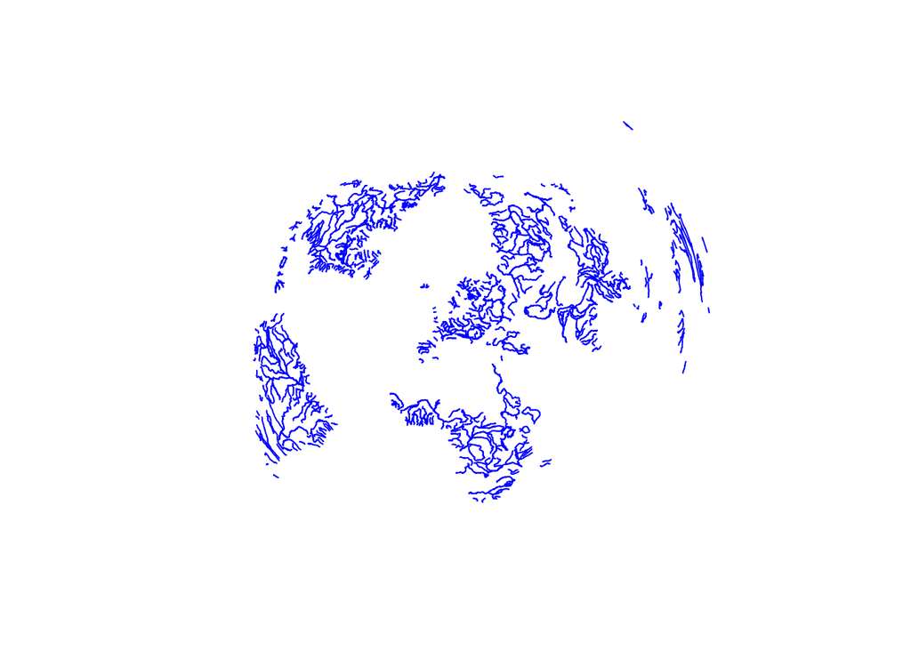

```r
plot(shape.nouveau,col="blue")
```

## 5. Les routes

Pour les **routes**, on a compris. Il suffit de trouver la base, de l’importer, de la lire, et de la visualiser. Avec là encore un simple appel de la fonction `plot()` pour garder une forme minimaliste.

La base est sur Natural Earth ; les fonctions `readShapeLines` et `plot(shape,pch=19,lwd=.7)` nous permettent de tracer la carte.

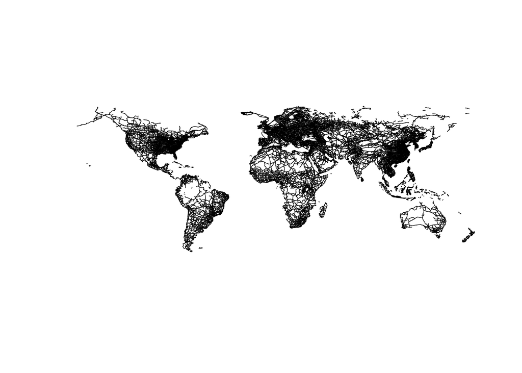

```r
getdatazip("http://www.naturalearthdata.com/http//www.naturalearthdata.com/download/10m/cultural/ne_10m_roads.zip", "data/routes.zip", 'data/routes/')
shape <- readShapeLines("data/routes/ne_10m_roads.shp")
plot(shape,pch=19,lwd=.7)
```

(Un lecteur nous signale qu’il y a sur notre carte des “routes” reliant l’Islande, la Norvège et la Grande-Bretagne; ce sont probablement des ferry.)

## 6. Les lacs

Les lacs se trouvent eux aussi sur Natural Earth. Cette fois, les objets sont des polygones, c’est à dire une collection de sommets reliés entre eux ; on emploie la commande `readShapePoly` pour les importer.

```r
getdatazip("http://www.naturalearthdata.com/http//www.naturalearthdata.com/download/10m/physical/ne_10m_lakes.zip", "data/lacs.zip", "data/lacs/")
shape <- readShapePoly("data/lacs/ne_10m_lakes.shp")
```

Nous obtenons 1 353 lacs. L’objet `shape@polygons[[3]]` contient le (ou les) polygones décrivant le troisième lac. Le premier de ces polygones est décrit par :

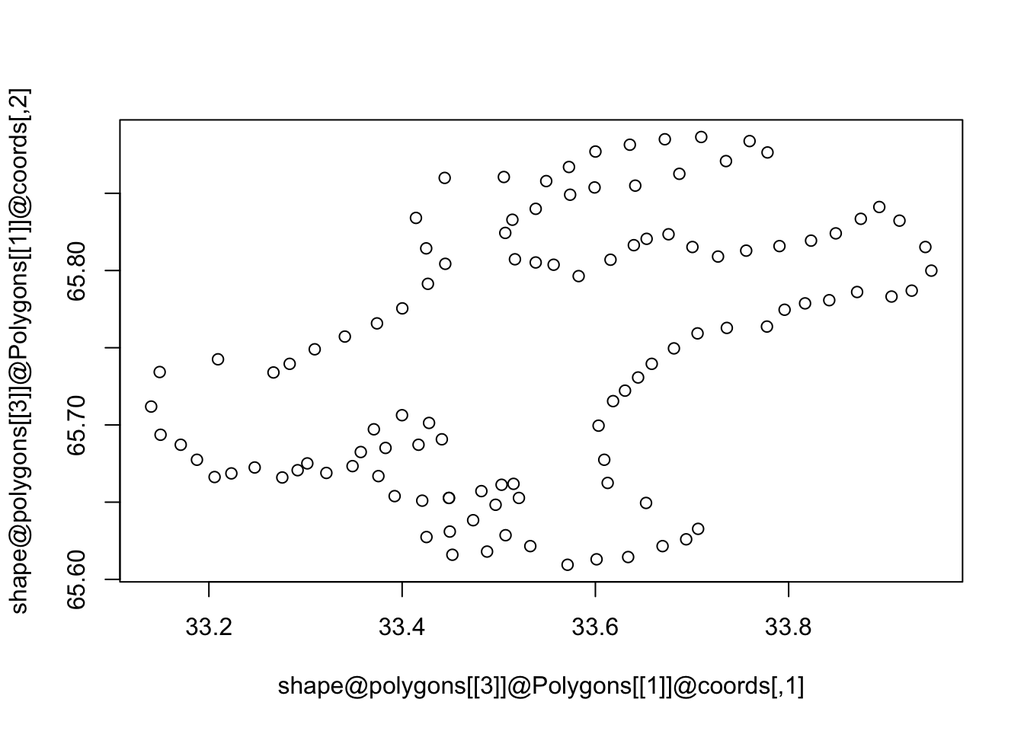

```r
plot(shape@polygons[[3]]@Polygons[[1]]@coords)
```

On peut fermer ce polygone et le remplir en bleu :

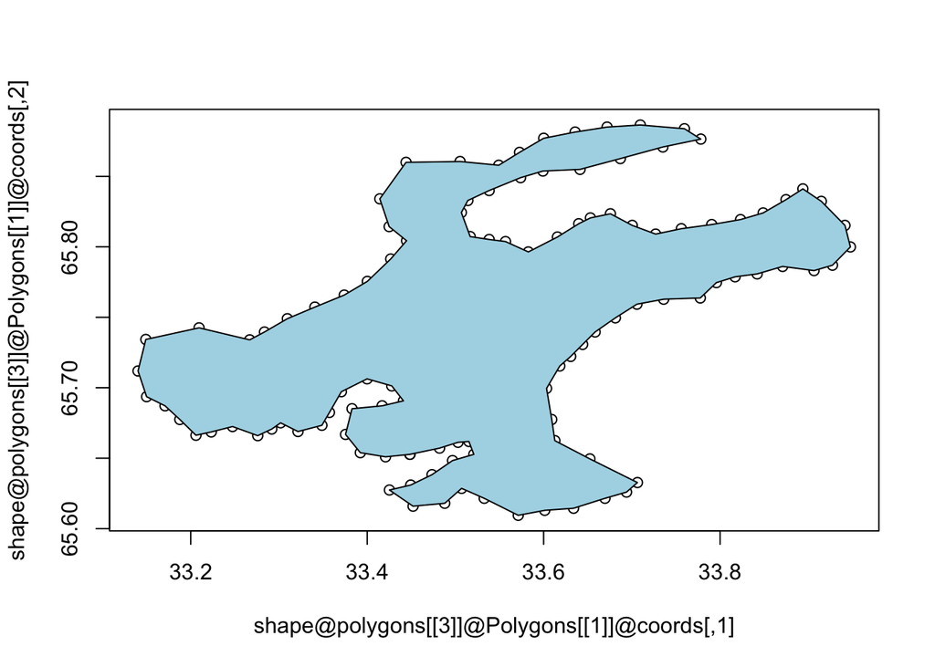

```r
plot(shape@polygons[[3]]@Polygons[[1]]@coords)
polygon(shape@polygons[[3]]@Polygons[[1]]@coords,col="light blue")
```

C’est ce que l’on va faire, avec tous nos polygones de lacs.

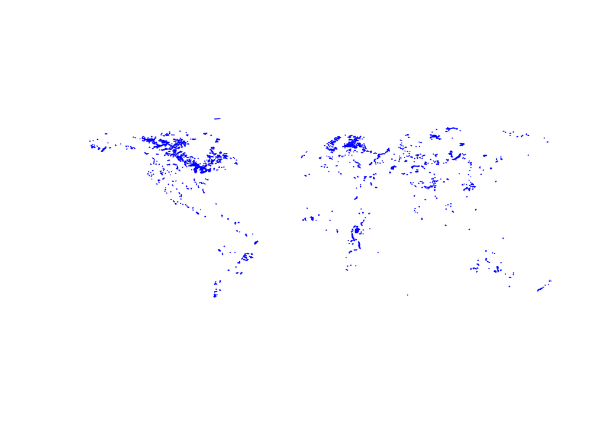

```r
plot(shape,col="blue",border="blue")
```